# Perception (Lineups)

Emily Robinson

Spring 2022

# 1 Data

| participant_id | age | gender | academic_study | dataset_id | curvature | scale | correct | response_no | binary_response | conf_level |
| --- | --- | --- | --- | --- | --- | --- | --- | --- | --- | --- |
| 0f7fc4ff03ad53f80b84cc62c1644648 | 19-25 | Female | High School or Less | b8efad9285426a191f979b32a5094198 | t-H_n-E | log | 9 | 14 | 0 | Certain |
| 0f7fc4ff03ad53f80b84cc62c1644648 | 19-25 | Female | High School or Less | 909f6bb4a0bbb8708bcc2d96c0b7052f | t-E_n-H | linear | 17 | 17 | 1 | Very Certain |
| 0f7fc4ff03ad53f80b84cc62c1644648 | 19-25 | Female | High School or Less | 70eebf16937fb9e77a3b806afe9aa528 | t-M_n-H | log | 13 | 13,16 | 1 | Very Certain |
| 0f7fc4ff03ad53f80b84cc62c1644648 | 19-25 | Female | High School or Less | 914e02881a7432dc34831c5dff0477e0 | t-H_n-M | log | 12 | 3 | 0 | Certain |
| 0f7fc4ff03ad53f80b84cc62c1644648 | 19-25 | Female | High School or Less | 8105c77bcc5d38d9b4e742f1b76de5fc | t-E_n-H | linear | 15 | 15 | 1 | Very Certain |
| 0f7fc4ff03ad53f80b84cc62c1644648 | 19-25 | Female | High School or Less | 076f2d6385d635ea49402478f7e44cab | t-E_n-M | linear | 14 | 9 | 0 | Uncertain |

# 2 Analysis

Target plot identification was analyzed using the `glmer` function in the `lme4` R package. Estimates and odds ratio comparisons between the log and linear scales were calculated using the `emmeans` R package. Each lineup plot evaluated was assigned a value based on the participant response (correct = 1, not correct = 0). Define $Y_{ijkl}$ to be the event that participant $l = 1,...,N_{participant}$ correctly identifies the target plot for data set $k = 1,2$ with curvature combination $j = 1,2,3,4,5,6$ plotted on scale $i = 1,2$. The binary response was analyzed using a generalized linear mixed model following a binomial distribution with a logit link function with a row-column blocking design accounting for the variation due to participant and data set respectively as
$$\begin{equation}
\text{logit }P(Y_{ijk}) = \eta + \delta_i + \gamma_j + \delta
\gamma_{ij} + s_l + d_k
\end{equation}$$
where

- $\eta$ is the baseline average probability of selecting the target plot
- $\delta_i$ is the effect of scale $i = 1,2$
- $\gamma_j$ is the effect of curvature combination $j = 1,2,3,4,5,6$
- $\delta\gamma_{ij}$ is the two-way interaction between the $i^{th}$ scale and $j^{th}$ curvature combination
- $s_l \sim N(0,\sigma^2_\text{participant})$is the random effect for participant characteristics
- $d_k \sim N(0,\sigma^2_{\text{data}})$ is the random effect for data specific characteristics.

We assume that random effects for data set and participant are independent.

```
## Generalized linear mixed model fit by maximum likelihood (Laplace
##   Approximation) [glmerMod]
##  Family: binomial  ( logit )
## Formula: binary_response ~ curvature * scale + (1 | participant_id) +
##     (1 | dataset_id)
##    Data: lineup_model_data
##
##      AIC      BIC   logLik deviance df.resid
##   3705.9   3793.9  -1839.0   3677.9     3944
##
## Scaled residuals:
##     Min      1Q  Median      3Q     Max
## -5.7555 -0.4750  0.1915  0.5062 10.1682
##
## Random effects:
##  Groups         Name        Variance Std.Dev.
##  participant_id (Intercept) 1.193    1.092
##  dataset_id     (Intercept) 0.433    0.658
## Number of obs: 3958, groups:  participant_id, 311; dataset_id, 12
##
## Fixed effects:
##                           Estimate Std. Error z value Pr(>|z|)
## (Intercept)                 2.8571     0.5206   5.489 4.05e-08 ***
## curvaturet-E_n-M           -3.2995     0.7114  -4.638 3.52e-06 ***
## curvaturet-H_n-E           -2.5065     0.7069  -3.546 0.000392 ***
## curvaturet-H_n-M           -4.8317     0.7182  -6.727 1.73e-11 ***
## curvaturet-M_n-E           -6.6936     0.7622  -8.782  < 2e-16 ***
## curvaturet-M_n-H           -1.2935     0.7108  -1.820 0.068794 .
## scalelog                   -0.3333     0.2965  -1.124 0.261052
## curvaturet-E_n-M:scalelog   2.8893     0.3884   7.440 1.01e-13 ***
## curvaturet-H_n-E:scalelog   1.7467     0.3638   4.801 1.58e-06 ***
## curvaturet-H_n-M:scalelog   2.1571     0.3640   5.926 3.11e-09 ***
## curvaturet-M_n-E:scalelog   4.2127     0.4449   9.469  < 2e-16 ***
## curvaturet-M_n-H:scalelog  -1.2457     0.3603  -3.457 0.000546 ***
## ---
## Signif. codes:  0 '***' 0.001 '**' 0.01 '*' 0.05 '.' 0.1 ' ' 1
##
## Correlation of Fixed Effects:
##             (Intr) cr-E_-M cr-H_-E cr-H_-M cr-M_-E cr-M_-H scallg c-E_-M:
## crvtrt-E_-M -0.722
```

[output cut: 9 more lines]

```
## crvtr-M_-H:  0.252 -0.184  -0.187  -0.181  -0.168  -0.280  -0.822  0.619
##             c-H_-E: c-H_-M: c-M_-E:
## crvtrt-E_-M
## crvtrt-H_-E
## crvtrt-H_-M
## crvtrt-M_-E
## crvtrt-M_-H
## scalelog
## crvtr-E_-M:
## crvtr-H_-E:
## crvtr-H_-M:  0.670
## crvtr-M_-E:  0.549   0.556
## crvtr-M_-H:  0.665   0.664   0.540
## optimizer (Nelder_Mead) convergence code: 0 (OK)
## Model failed to converge with max|grad| = 0.0536203 (tol = 0.002, component 1)
```

Lineups GLMM ANOVA

| term | statistic | df | p.value |
| --- | --- | --- | --- |
| curvature | 32.230 | 5 | 0 |
| scale | 96.664 | 1 | 0 |
| curvature:scale | 294.443 | 5 | 0 |

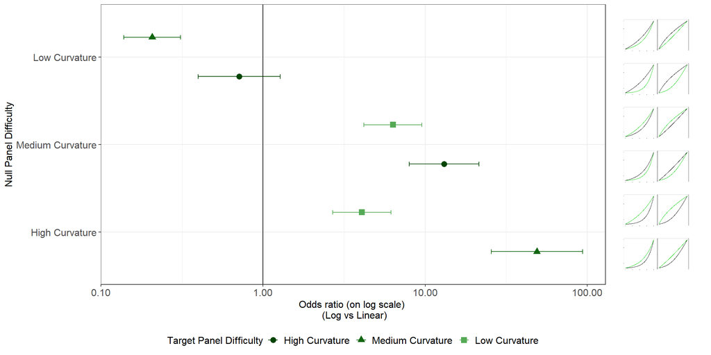